# projectTM - final

Have used Total Emissions Per Country sheet from our dataset. The data includes the following columns: Area (country), Item, Element, Unit, and yearly emissions from 2000 to 2020.The below code tries to do the folowing:

```python
import numpy as np
import pandas as pd
import matplotlib.pyplot as plt
import seaborn as sns
```

Loading the data to work with:

```python
file_path = pd.ExcelFile("compiled_carbon_dataTM.xlsx")
df = pd.read_excel(file_path, sheet_name='Total Emissions Per Country')
display(df)
```

|  | Area | Item | Element | Unit | 2000 | 2001 | 2002 | 2003 | 2004 | 2005 | ... | 2011 | 2012 | 2013 | 2014 | 2015 | 2016 | 2017 | 2018 | 2019 | 2020 |
| --- | --- | --- | --- | --- | --- | --- | --- | --- | --- | --- | --- | --- | --- | --- | --- | --- | --- | --- | --- | --- | --- |
| 0 | Afghanistan | Crop Residues | Direct emissions (N2O) | kilotonnes | 0.5200 | 0.5267 | 0.8200 | 0.9988 | 0.8225 | 1.1821 | ... | 1.0321 | 1.3726 | 1.4018 | 1.4584 | 1.2424 | 1.1940 | 1.0617 | 0.8988 | 1.2176 | 1.3170 |
| 1 | Afghanistan | Crop Residues | Indirect emissions (N2O) | kilotonnes | 0.1170 | 0.1185 | 0.1845 | 0.2247 | 0.1851 | 0.2660 | ... | 0.2322 | 0.3088 | 0.3154 | 0.3281 | 0.2795 | 0.2687 | 0.2389 | 0.2022 | 0.2740 | 0.2963 |
| 2 | Afghanistan | Crop Residues | Emissions (N2O) | kilotonnes | 0.6370 | 0.6452 | 1.0045 | 1.2235 | 1.0075 | 1.4481 | ... | 1.2643 | 1.6815 | 1.7173 | 1.7865 | 1.5220 | 1.4627 | 1.3005 | 1.1011 | 1.4916 | 1.6133 |
| 3 | Afghanistan | Crop Residues | Emissions (CO2eq) from N2O (AR5) | kilotonnes | 168.8070 | 170.9884 | 266.1975 | 324.2195 | 266.9995 | 383.7498 | ... | 335.0379 | 445.5958 | 455.0727 | 473.4174 | 403.3181 | 387.6130 | 344.6447 | 291.7838 | 395.2689 | 427.5284 |
| 4 | Afghanistan | Crop Residues | Emissions (CO2eq) (AR5) | kilotonnes | 168.8070 | 170.9884 | 266.1975 | 324.2195 | 266.9995 | 383.7498 | ... | 335.0379 | 445.5958 | 455.0727 | 473.4174 | 403.3181 | 387.6130 | 344.6447 | 291.7838 | 395.2689 | 427.5284 |
| ... | ... | ... | ... | ... | ... | ... | ... | ... | ... | ... | ... | ... | ... | ... | ... | ... | ... | ... | ... | ... | ... |
| 40936 | Polynesia | AFOLU | Emissions (N2O) | kilotonnes | 0.2537 | 0.2515 | 0.2457 | 0.2504 | 0.2576 | 0.2511 | ... | 0.2919 | 0.2875 | 0.2917 | 0.2916 | 0.3112 | 0.2907 | 0.2845 | 0.2914 | 0.2485 | 0.2730 |
| 40937 | Polynesia | AFOLU | Emissions (CO2) | kilotonnes | -78.5371 | 37.8016 | 37.8016 | 37.8016 | 37.8016 | 37.8016 | ... | 68.3054 | 68.3054 | 68.3054 | 68.3054 | 68.3054 | 59.9930 | 59.9930 | 59.9930 | 59.9930 | 59.9930 |
| 40938 | Polynesia | AFOLU | Emissions (CO2eq) from CH4 (AR5) | kilotonnes | 250.9632 | 256.0386 | 250.4268 | 253.5861 | 259.6563 | 255.8941 | ... | 274.8879 | 277.0859 | 280.2901 | 281.0791 | 292.3387 | 274.5266 | 264.7954 | 269.2992 | 225.7938 | 247.2653 |
| 40939 | Polynesia | AFOLU | Emissions (CO2eq) from N2O (AR5) | kilotonnes | 67.2278 | 66.6490 | 65.1051 | 66.3669 | 68.2670 | 66.5313 | ... | 77.3592 | 76.1890 | 77.2992 | 77.2639 | 82.4713 | 77.0330 | 75.3892 | 77.2137 | 65.8571 | 72.3495 |
| 40940 | Polynesia | AFOLU | Emissions (CO2eq) (AR5) | kilotonnes | 239.6539 | 360.4892 | 353.3335 | 357.7545 | 365.7248 | 360.2270 | ... | 420.5524 | 421.5803 | 425.8947 | 426.6484 | 443.1153 | 411.5525 | 400.1776 | 406.5058 | 351.6438 | 379.6078 |

40941 rows × 25 columns

Below code snippet performs the follwoing steps:

1. Initializes a dictionary to store top 3 countries per year
2. Calculates the sum of emissions for each country for the year and get the top 3
3. Converts the dictionary to a DataFrame for easier manipulation
4. Transposes the DataFrame for plotting
5. Plots the results

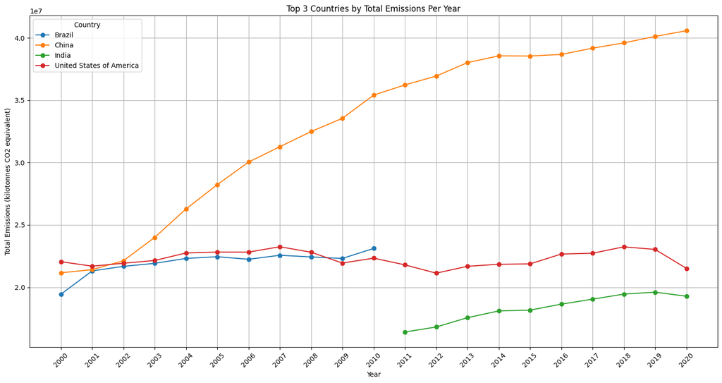

```python
top_3_per_year = {}
years = list(range(2000, 2021))

for year in years:
    top_3_per_year[year] = df.groupby('Area')[year].sum().nlargest(3)

top_3_per_year_df = pd.DataFrame(top_3_per_year)
transposed_df = top_3_per_year_df.transpose()

plt.figure(figsize=(15, 8))
for country in transposed_df.columns:
    plt.plot(years, transposed_df[country], label=country, marker='o')
plt.title('Top 3 Countries by Total Emissions Per Year')
plt.xlabel('Year')
plt.ylabel('Total Emissions (kilotonnes CO2 equivalent)')
plt.legend(title='Country')
plt.grid(True)
plt.xticks(years, rotation=45)
plt.tight_layout()
plt.show()
```

Now we want to find top three contributing items to emissions for each of the above four countries, along with their total quantities summed across all years by the following steps:

1. Ensure that all year columns are identified correctly, assuming year columns are numeric but need to be checked as string
2. Group by 'Area' and 'Item', then sum only the year columns
3. Define the top countries
4. Initialize a dictionary to store the top 3 items per country
5. Sum emissions across all years for each item within the specific country and get the top 3 items with the highest emissions, storing the results in a dictionary
6. Display the results

```python
year_columns = [col for col in df.columns if isinstance(col, int) or col.isdigit()]

item_emissions = df.groupby(['Area', 'Item'])[year_columns].sum()
top_countries = ["China", "United States of America", "India", "Brazil"]
top_items_per_country = {}

for country in top_countries:
    total_emissions = item_emissions.loc[country].sum(axis=1)
    top_3_items = total_emissions.nlargest(3)
    top_items_per_country[country] = top_3_items

for country, items in top_items_per_country.items():
    print(f"{country}:")
    for item, total in items.items():
        print(f"{item}: {total / 1e6:.5f} million kilotonnes CO2 equivalent")
    print()
```

```
China:
Energy: 348.28853 million kilotonnes CO2 equivalent
Agri-food systems: 70.63832 million kilotonnes CO2 equivalent
IPPU: 50.61408 million kilotonnes CO2 equivalent

United States of America:
Energy: 240.09780 million kilotonnes CO2 equivalent
Agri-food systems: 47.24500 million kilotonnes CO2 equivalent
IPCC Agriculture: 40.55940 million kilotonnes CO2 equivalent

India:
Energy: 76.51425 million kilotonnes CO2 equivalent
Agri-food systems: 51.04748 million kilotonnes CO2 equivalent
Emissions on agricultural land: 32.39468 million kilotonnes CO2 equivalent

Brazil:
Agri-food systems: 77.17797 million kilotonnes CO2 equivalent
Emissions on agricultural land: 71.64115 million kilotonnes CO2 equivalent
AFOLU: 52.02146 million kilotonnes CO2 equivalent
```

Now, when we have identified the top contrubutor countries, we prepared 2x2 pie charts representing the top three emission items for them (China, the United States of America, India, and Brazil). Each pie chart displays the proportion of total emissions contributed by the top three items for each country. Steps are:

1. Sample data prepared from the previous discussion assuming we have the top 3 items per country with their emissions
2. Create a 2x2 grid of pie charts Flattening it into a 1D array for easier indexing
3. Iterate over each country and its top 3 items, creating a pie chart for each
4. Adjust layout to prevent overlap and display it

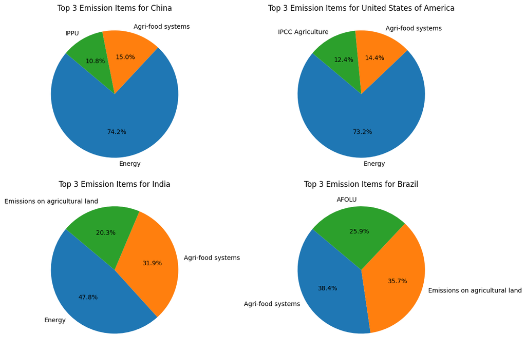

```python
top_items_per_country = {
    'China': {'Energy': 348288500, 'Agri-food systems': 70638320, 'IPPU': 50614080},
    'United States of America': {'Energy': 240097800, 'Agri-food systems': 47245000, 'IPCC Agriculture': 40559400},
    'India': {'Energy': 76514250, 'Agri-food systems': 51047480, 'Emissions on agricultural land': 32394680},
    'Brazil': {'Agri-food systems': 77177970, 'Emissions on agricultural land': 71641150, 'AFOLU': 52021460}
}

fig, axs = plt.subplots(2, 2, figsize=(12, 8))
axs = axs.flatten()

for idx, (country, items) in enumerate(top_items_per_country.items()):
    sizes = items.values()
    labels = items.keys()
    axs[idx].pie(sizes, labels=labels, autopct='%1.1f%%', startangle=140)
    axs[idx].set_title(f'Top 3 Emission Items for {country}')

plt.tight_layout()
plt.show()
```

Now we have done some visualisation a another part of our dataset, that represents climate change statistics per country from 1961 to 2022 years.

```python
# filling missing values
data = pd.read_excel(file_path, sheet_name='climate_change_indicators')
yearly_columns = data.columns[data.columns.get_loc('F1961'):data.columns.get_loc('F2022')+1]
data[yearly_columns] = data[yearly_columns].interpolate(method='linear', axis=0)
data
```

|  | ObjectId | Country | ISO2 | ISO3 | Indicator | Unit | Source | CTS_Code | CTS_Name | CTS_Full_Descriptor | ... | F2013 | F2014 | F2015 | F2016 | F2017 | F2018 | F2019 | F2020 | F2021 | F2022 |
| --- | --- | --- | --- | --- | --- | --- | --- | --- | --- | --- | --- | --- | --- | --- | --- | --- | --- | --- | --- | --- | --- |
| 0 | 1 | Afghanistan, Islamic Rep. of | AF | AFG | Temperature change with respect to a baseline ... | Degree Celsius | Food and Agriculture Organization of the Unite... | ECCS | Surface Temperature Change | Environment, Climate Change, Climate Indicator... | ... | 1.281 | 0.456 | 1.093 | 1.5550 | 1.540 | 1.544 | 0.9100 | 0.498 | 1.3270 | 2.012 |
| 1 | 2 | Albania | AL | ALB | Temperature change with respect to a baseline ... | Degree Celsius | Food and Agriculture Organization of the Unite... | ECCS | Surface Temperature Change | Environment, Climate Change, Climate Indicator... | ... | 1.333 | 1.198 | 1.569 | 1.4640 | 1.121 | 2.028 | 1.6750 | 1.498 | 1.5360 | 1.518 |
| 2 | 3 | Algeria | DZ | DZA | Temperature change with respect to a baseline ... | Degree Celsius | Food and Agriculture Organization of the Unite... | ECCS | Surface Temperature Change | Environment, Climate Change, Climate Indicator... | ... | 1.192 | 1.690 | 1.121 | 1.7570 | 1.512 | 1.210 | 1.1150 | 1.926 | 2.3300 | 1.688 |
| 3 | 4 | American Samoa | AS | ASM | Temperature change with respect to a baseline ... | Degree Celsius | Food and Agriculture Organization of the Unite... | ECCS | Surface Temperature Change | Environment, Climate Change, Climate Indicator... | ... | 1.257 | 1.170 | 1.009 | 1.5390 | 1.435 | 1.189 | 1.5390 | 1.430 | 1.2680 | 1.256 |
| 4 | 5 | Andorra, Principality of | AD | AND | Temperature change with respect to a baseline ... | Degree Celsius | Food and Agriculture Organization of the Unite... | ECCS | Surface Temperature Change | Environment, Climate Change, Climate Indicator... | ... | 0.831 | 1.946 | 1.690 | 1.9900 | 1.925 | 1.919 | 1.9640 | 2.562 | 1.5330 | 3.243 |
| ... | ... | ... | ... | ... | ... | ... | ... | ... | ... | ... | ... | ... | ... | ... | ... | ... | ... | ... | ... | ... | ... |
| 220 | 221 | Western Sahara | EH | ESH | Temperature change with respect to a baseline ... | Degree Celsius | Food and Agriculture Organization of the Unite... | ECCS | Surface Temperature Change | Environment, Climate Change, Climate Indicator... | ... | 1.423 | 1.401 | 1.510 | 1.7320 | 2.204 | 0.942 | 1.4770 | 2.069 | 1.5930 | 1.970 |
| 221 | 222 | World | NaN | WLD | Temperature change with respect to a baseline ... | Degree Celsius | Food and Agriculture Organization of the Unite... | ECCS | Surface Temperature Change | Environment, Climate Change, Climate Indicator... | ... | 1.016 | 1.053 | 1.412 | 1.6600 | 1.429 | 1.290 | 1.4440 | 1.711 | 1.4470 | 1.394 |
| 222 | 223 | Yemen, Rep. of | YE | YEM | Temperature change with respect to a baseline ... | Degree Celsius | Food and Agriculture Organization of the Unite... | ECCS | Surface Temperature Change | Environment, Climate Change, Climate Indicator... | ... | 0.903 | 0.985 | 1.431 | 1.5305 | 0.767 | 0.969 | 1.1495 | 1.301 | 1.1345 | 1.040 |
| 223 | 224 | Zambia | ZM | ZMB | Temperature change with respect to a baseline ... | Degree Celsius | Food and Agriculture Organization of the Unite... | ECCS | Surface Temperature Change | Environment, Climate Change, Climate Indicator... | ... | 0.790 | 0.917 | 1.450 | 1.4010 | 0.105 | 0.648 | 0.8550 | 0.891 | 0.8220 | 0.686 |
| 224 | 225 | Zimbabwe | ZW | ZWE | Temperature change with respect to a baseline ... | Degree Celsius | Food and Agriculture Organization of the Unite... | ECCS | Surface Temperature Change | Environment, Climate Change, Climate Indicator... | ... | 0.118 | 0.025 | 0.970 | 1.2700 | 0.088 | 0.453 | 0.9250 | 0.389 | -0.1250 | -0.490 |

225 rows × 72 columns

From this particular dataset we want to extratc top 5 countries that had the highest average change degree for all the periods, by the following steps:

1. Calculate the mean temperature change for each country over the years
2. Sort the countries based on the average temperature change in descending order
3. Display the top 5 countries with the highest average temperature change

```python
data['Average_Temperature_Change'] = data[yearly_columns].mean(axis=1)

sorted_data = data.sort_values(by='Average_Temperature_Change', ascending=False)

top_5_countries = sorted_data[['Country', 'Average_Temperature_Change']].head(5)
top_5_countries
```

|  | Country | Average_Temperature_Change |
| --- | --- | --- |
| 132 | Mongolia | 0.895597 |
| 125 | Mauritania, Islamic Rep. of | 0.893597 |
| 62 | Estonia, Rep. of | 0.828126 |
| 12 | Austria | 0.809371 |
| 220 | Western Sahara | 0.805548 |

A heatmap

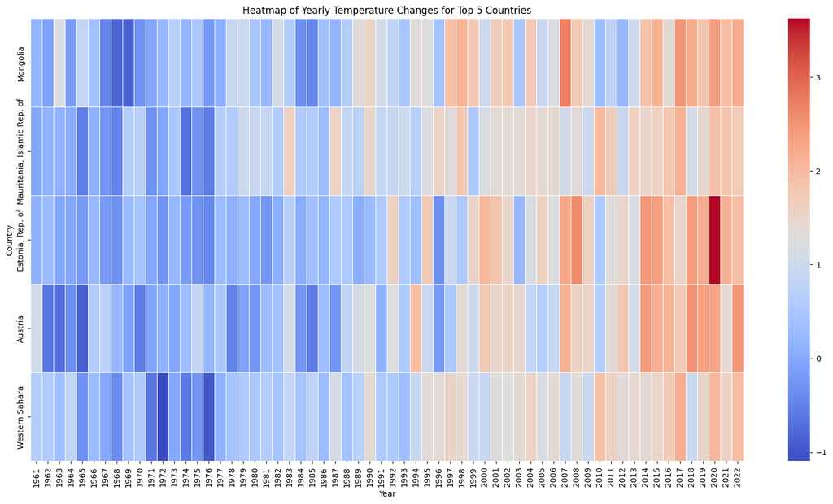

```python
top_5_data = data[data['Country'].isin(top_5_countries['Country'])]
box_plot_data = [top_5_data[top_5_data['Country'] == country][yearly_columns].values.flatten() for country in top_5_countries['Country']]

heatmap_data = pd.DataFrame()
for country in top_5_countries['Country']:
    heatmap_data[country] = top_5_data[top_5_data['Country'] == country][yearly_columns].iloc[0].values

heatmap_data = heatmap_data.T
heatmap_data.columns = np.arange(1961, 2023)

plt.figure(figsize=(20, 10))
sns.heatmap(heatmap_data, annot=False, cmap='coolwarm', linewidths=.5)
plt.title('Heatmap of Yearly Temperature Changes for Top 5 Countries')
plt.xlabel('Year')
plt.ylabel('Country')
plt.show()
```